# starmie: Admixture models

Stuart Lee, Gerry Tonkin-Hill

2016-11-07

In this vignette we use `starmie` to perform visualisation and inference on a sequence of ADMIXTURE models fit on the [sample data](https://www.genetics.ucla.edu/software/admixture/download.html) supplied by the creators of ADMIXTURE.

# Loading ADMIXTURE output and the ‘admix’ object

To begin we assume ADMIXTURE has been run on an example PED/BED file to analyse and there is a directory containing the resulting .P, .Q and logging files (if you want to perform inference).

To read a single ADMIXTURE run first supply the names of .P and .Q file and save it as an admix object using the `loadAdmixture` function.

```r
library(starmie)
# get Q and P files for K = 3
p3 <- system.file("extdata/hapmap3_files", "hapmap3.3.P", package = "starmie")
q3 <- system.file("extdata/hapmap3_files", "hapmap3.3.Q", package = "starmie")

k3_admix <- loadAdmixture(q3, p3)
k3_admix
```

```
## admix object containing run information for k = 3
## Model parameters:
##    No. samples: 324
##    No. markers: 13928
## Model diagnostics available: FALSE
```

Optionally, if you would like to look at model fit statstics you can read in a log file as well. Now the admix object contains the estimated log-likelihood and cross-validation error.

```r
k3_log <- system.file("extdata/hapmap3_files", "log3.out", package = "starmie")

k3_admix <- loadAdmixture(q3, p3, k3_log)
k3_admix
```

```
## admix object containing run information for k = 3
## Model parameters:
##    No. samples: 324
##    No. markers: 13928
## Model diagnostics available: TRUE
## Model fit statistics:
##   K     logL CVerror
## 1 3 -3799887 0.47835
```

In general an `admix` object consists of the following elements about a single ADMIXTURE run:

| attributes | description |
| --- | --- |
| K | K parameter supplied to ADMIXTURE |
| nsamples | Number of samples |
| nmarkers | Number of markers |
| Q_df | Individual ancestral probability of membership to cluster |
| P_df | Estimated ancestral allele frequencies for each cluster |
| log_info | Model fit statistics |

## Constructing a barplot for a single admix object

The plotBar function works on `admix` objects and produces a facetted barplot in the same manner as for `struct` objects.

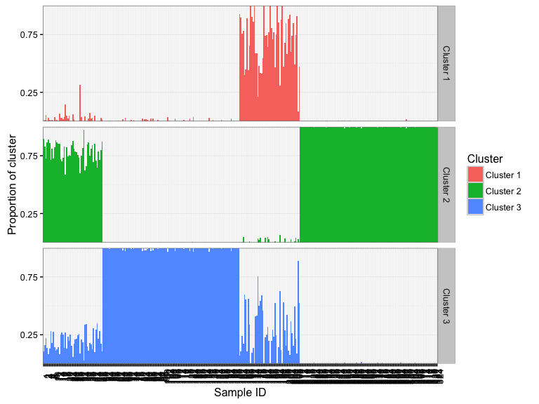

```r
plotBar(k3_admix)
```

A regular barplot can be constructed by setting `facet = FALSE`.

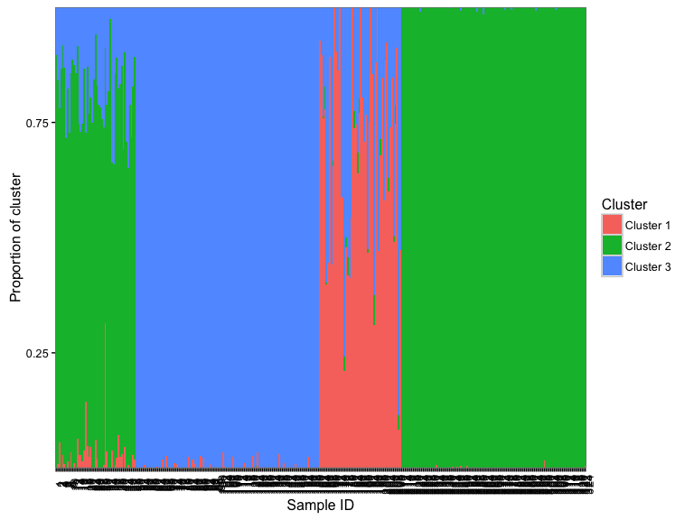

```r
plotBar(k3_admix, facet = FALSE)
```

## Putting admix objects together the `admixList` object

If you have tried running ADMIXTURE with many different values of $K$ then you can use an `admixList` object to maninpulate them. To construct an `admixList` object use `loadAdmixture` for each pair of Q and P files and then pass the results to the `admixList` constructor function.

```r
admix_multi <- exampleAdmixture()
admix_multi
```

```
## admixList object containing 5  ADMIXTURE runs.
## Number of Ks by number of runs:
## 1 2 3 4 5
## 1 1 1 1 1
## Model fit information by K:
##   K     logL CVerror
## 1 1 -4169323 0.55248
## 2 2 -3835365 0.48190
## 3 3 -3799887 0.47835
## 4 4 -3789059 0.48236
## 5 5 -3778956 0.49001
```

You can also plot multiple `admix` objects to see how cluster memberships change for different values of $K$.

[output not shown]

## Using ADMIXTURE output to perform inference.

The `bestK` method can be used to determine which value of `K` best explains the observed data using an elbow plot on the cross-validation error.

```r
bestK(admix_multi)
```

```
## Creating diagnositc plots for admixture runs
```

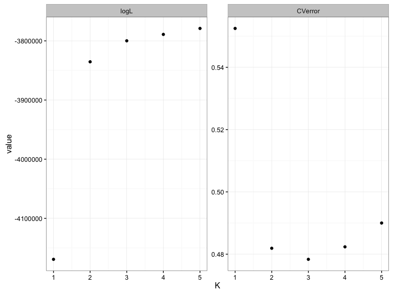

```
##   K     logL CVerror
## 1 1 -4169323 0.55248
## 2 2 -3835365 0.48190
## 3 3 -3799887 0.47835
## 4 4 -3789059 0.48236
## 5 5 -3778956 0.49001
```

# References

Alexander, D. H., Novembre, J. & Lange, K. Fast model-based estimation of ancestry in unrelated individuals. Genome Res. 19, 1655–1664 (2009).